# What Do Microbial Kingdoms Share?

rajiveplus development team

2026-06-10

# 1 The question

A gut microbiome is not one ecosystem measured three times. Bacteria, fungi, and viruses can move together, or they can carry kingdom-specific variation. This vignette uses **rajiveplus** on the multi-kingdom gut microbiome data from [Haak *et al.* (2021)](https://doi.org/10.1038/s41586-021-03406-7) to separate those two possibilities.

The cohort contains 57 patients with matched measurements across three microbial kingdoms - **Bacteria** (16S rRNA, 180 OTUs), **Fungi** (ITS2, 18 OTUs), and **Viruses** (virome sequencing, 42 viral families) - plus clinical metadata including antibiotic exposure and short-chain fatty acid profiles.

| Kingdom | Technology | Features |
| --- | --- | --- |
| Bacteria | 16S rRNA | 180 OTUs |
| Fungi | ITS2 | 18 OTUs |
| Viruses | virome-seq | 42 vOTUs |

## 1.1 Scientific question

Can RaJIVE find a shared microbiome axis across kingdoms, and can it separate that axis from bacteria-, fungi-, or virus-specific structure?

# 2 Prerequisites

```r
library(rajiveplus)
library(ggplot2)
library(dplyr)
library(tidyr)
library(knitr)

theme_set(theme_bw(base_size = 13))
```

# 3 Data loading

The rendered vignette reads cached RDS files. That keeps the article reproducible without requiring a fresh download from the source archive.

```r
raw  <- readRDS(file.path(data_dir, "microbiome_raw.rds"))
meta <- raw$metadata
dt   <- raw$dt   # long-format: columns sample, feature, view, value

cat("Long-format data :", nrow(dt), "rows x", ncol(dt), "cols\n")
```

```
## Long-format data : 14076 rows x 4 cols
```

```r
cat("Kingdoms (views) :", paste(sort(unique(dt$view)), collapse = ", "), "\n")
```

```
## Kingdoms (views) : Bacteria, Fungi, Viruses
```

```r
cat("Total samples    :", length(unique(dt$sample)), "\n")
```

```
## Total samples    : 59
```

```r
cat("Metadata samples :", nrow(meta), "\n")
```

```
## Metadata samples : 59
```

```r
# Summarise per-kingdom feature counts
kingdom_summary <- dt |>
  dplyr::group_by(view) |>
  dplyr::summarise(n_samples  = dplyr::n_distinct(sample),
                   n_features = dplyr::n_distinct(feature),
                   .groups    = "drop")
knitr::kable(kingdom_summary, caption = "Features and samples per kingdom")
```

Features and samples per kingdom

| view | n_samples | n_features |
| --- | --- | --- |
| Bacteria | 59 | 180 |
| Fungi | 59 | 18 |
| Viruses | 57 | 42 |

## 3.1 What scale are the values on?

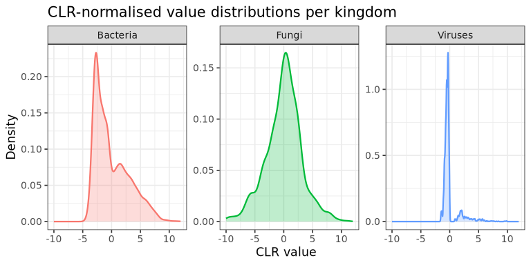

```r
ggplot(dt, aes(x = value, colour = view, fill = view)) +
  geom_density(alpha = 0.25, linewidth = 0.8) +
  facet_wrap(~view, scales = "free_y", nrow = 1) +
  labs(title = "CLR-normalised value distributions per kingdom",
       x = "CLR value", y = "Density") +
  theme(legend.position = "none")
```

## 3.2 Which sample groups are present?

```r
if ("Category" %in% colnames(meta)) {
  cnt <- sort(table(meta$Category), decreasing = TRUE)
  knitr::kable(as.data.frame(cnt), col.names = c("Category", "Count"),
               caption = "Sample counts per category")
}
```

Sample counts per category

| Category | Count |
| --- | --- |
| Sepsis | 24 |
| Healthy, no antibiotics | 20 |
| Non septic ICU | 9 |
| Healthy, antibiotics | 6 |

# 4 Matched blocks

```r
pp      <- readRDS(file.path(data_dir, "microbiome_preprocessed.rds"))
blocks  <- pp$blocks    # named list: Bacteria / Fungi / Viruses
meta_s  <- pp$meta      # metadata aligned to the 57 common samples

cat("Block names :", paste(names(blocks), collapse = ", "), "\n")
```

```
## Block names : Bacteria, Fungi, Viruses
```

```r
cat("Block dims  :",
    paste(sapply(blocks, function(m) paste(dim(m), collapse = "x")), collapse = ", "), "\n")
```

```
## Block dims  : 57x180, 57x18, 57x42
```

```r
cat("Meta samples:", nrow(meta_s), "\n")
```

```
## Meta samples: 57
```

## 4.1 How much rank should each kingdom offer?

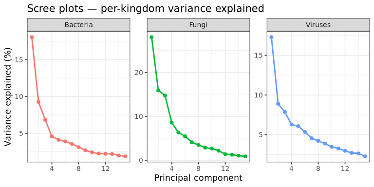

```r
svd_list <- readRDS(file.path(data_dir, "microbiome_svd_list.rds"))

scree_df <- do.call(rbind, lapply(names(svd_list), function(k) {
  sv   <- svd_list[[k]]
  rank <- min(length(sv), 15L)
  data.frame(kingdom = k,
             component = seq_len(rank),
             variance  = sv[seq_len(rank)]^2 / sum(sv^2),
             stringsAsFactors = FALSE)
}))

ggplot(scree_df, aes(x = component, y = variance * 100, colour = kingdom)) +
  geom_line(linewidth = 1) +
  geom_point(size = 2) +
  facet_wrap(~kingdom, scales = "free_y") +
  labs(title = "Scree plots — per-kingdom variance explained",
       x = "Principal component", y = "Variance explained (%)") +
  theme(legend.position = "none")
```

# 5 Fit the RaJIVE model

```r
mb_fit   <- readRDS(file.path(data_dir, "microbiome_rajive_results.rds"))
jr       <- get_joint_rank(mb_fit)
all_rnks <- get_all_ranks(mb_fit)   # named by block index "block1","block2","block3"

kingdom_names <- names(blocks)  # "Bacteria","Fungi","Viruses" (from pp$blocks)

cat("Joint rank      :", jr, "\n")
```

```
## Joint rank      : 1
```

```r
cat("Ranks per block :\n")
```

```
## Ranks per block :
```

```r
print(all_rnks)
```

```
##    block joint_rank individual_rank
## 1 block1          1               4
## 2 block2          1               4
## 3 block3          1               7
```

# 6 Was the joint rank convincing?

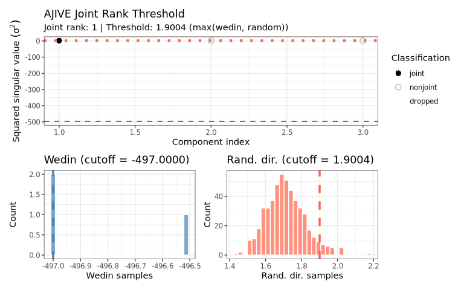

```r
plot_components(mb_fit, plot_type = "ajive_diagnostic") +
  labs(title = "RaJIVE rank diagnostic")
```

```r
ind_rank_df <- data.frame(
  Kingdom       = kingdom_names,
  `Joint rank`  = jr,
  `Indiv. rank` = sapply(seq_along(kingdom_names), function(i)
                    get_individual_rank(mb_fit, i)),
  stringsAsFactors = FALSE,
  check.names = FALSE
)
knitr::kable(ind_rank_df, caption = "Estimated ranks per kingdom")
```

Estimated ranks per kingdom

| Kingdom | Joint rank | Indiv. rank |
| --- | --- | --- |
| Bacteria | 1 | 4 |
| Fungi | 1 | 4 |
| Viruses | 1 | 7 |

# 7 Where does the variation live?

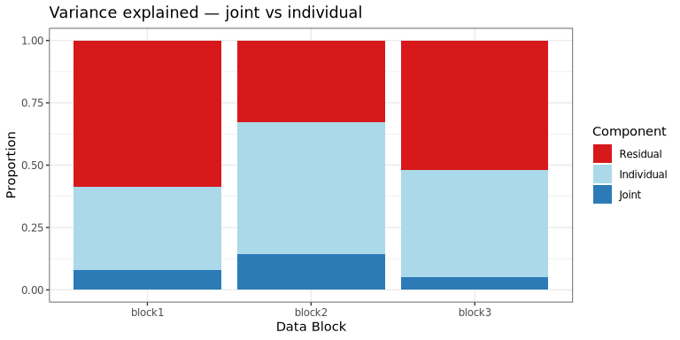

```r
plot_variance_explained(mb_fit, blocks) +
  labs(title = "Variance explained — joint vs individual")
```

```r
ve_tbl <- summarize_components(ajive_output = mb_fit,
                               blocks = blocks,
                               summary_type = "variance")
knitr::kable(ve_tbl, digits = 3,
             caption = "Proportion of variance explained")
```

Proportion of variance explained

| Joint | Indiv | Resid |
| --- | --- | --- |
| 0.081 | 0.334 | 0.585 |
| 0.142 | 0.531 | 0.327 |
| 0.050 | 0.433 | 0.518 |

# 8 What does the joint score track?

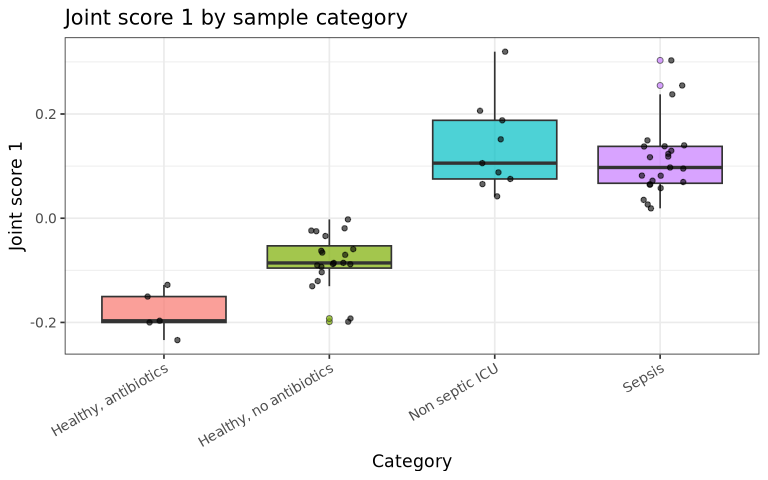

```r
J_scores <- get_joint_scores(mb_fit)   # n_samples × jr matrix

if (!is.null(J_scores) && jr >= 1) {
  score_df <- as.data.frame(J_scores)
  colnames(score_df) <- paste0("JS", seq_len(jr))
  # J_scores may lack rownames; use meta_s sample identifiers (same ordering)
  score_df$sample <- meta_s$sample

  # Merge with metadata
  meta_sub <- meta_s[, intersect(colnames(meta_s),
                                  c("sample", "Category", "Diagnosis", "Sexs")),
                     drop = FALSE]
  score_df <- merge(score_df, meta_sub, by = "sample", all.x = TRUE)

  if ("Category" %in% colnames(score_df)) {
    ggplot(score_df, aes(x = Category, y = JS1, fill = Category)) +
      geom_boxplot(alpha = 0.7, outlier.shape = 21) +
      geom_jitter(width = 0.15, size = 1.5, alpha = 0.6) +
      labs(title = "Joint score 1 by sample category",
           x = "Category", y = "Joint score 1") +
      theme(legend.position = "none",
            axis.text.x = element_text(angle = 30, hjust = 1))
  }
} else {
  message("Joint rank is 0 — no joint scores to plot.")
}
```

## 8.1 A two-dimensional joint map, if present

```r
if (!is.null(J_scores) && jr >= 2) {
  ggplot(score_df, aes(x = JS1, y = JS2,
                        colour = if ("Category" %in% colnames(score_df))
                                    Category else "grey")) +
    geom_point(size = 3, alpha = 0.8) +
    labs(title = "Joint scores 1 vs 2", colour = "Category")
}
```

# 9 Which features define the joint component?

[figure not shown]

[figure not shown]

[figure not shown]

```r
if (jr >= 1) {
  loading_plots <- lapply(seq_along(kingdom_names), function(i) {
    k  <- kingdom_names[i]
    ld <- tryCatch(
      rank_features(mb_fit, block = i, component = 1L, type = "joint"),
      error = function(e) NULL
    )
    if (is.null(ld)) return(NULL)
    top <- head(ld[order(abs(ld$loading), decreasing = TRUE), ], 15)
    ggplot(top, aes(x = reorder(feature_name, loading), y = loading,
                    fill = loading > 0)) +
      geom_col(width = 0.7) +
      coord_flip() +
      scale_fill_manual(values = c("steelblue", "tomato"), guide = "none") +
      labs(title = paste("Top loadings —", k, "(joint)"),
           x = NULL, y = "Loading")
  })
  loading_plots <- Filter(Negate(is.null), loading_plots)
  for (p in loading_plots) print(p)
}
```

# 10 What is kingdom-specific?

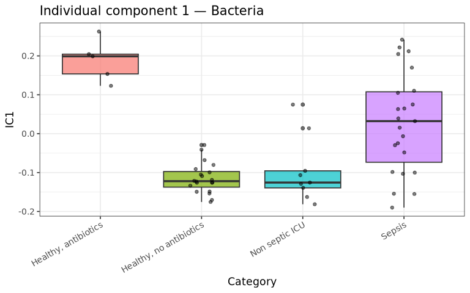

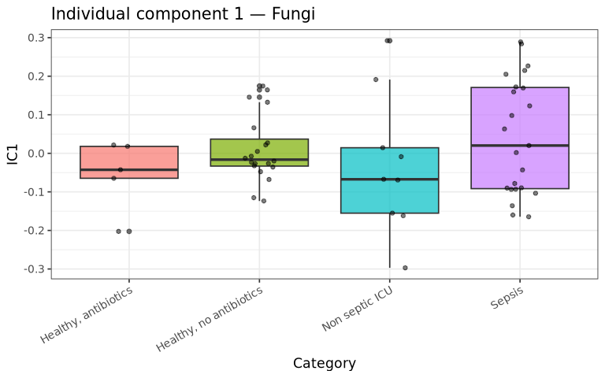

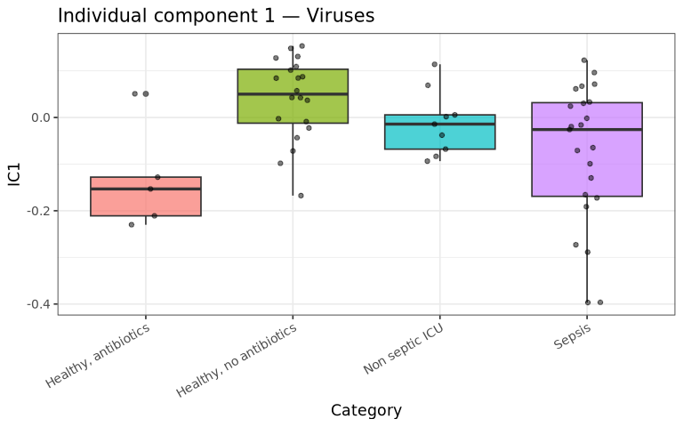

```r
for (i in seq_along(kingdom_names)) {
  k  <- kingdom_names[i]
  ir <- get_individual_rank(mb_fit, i)
  if (ir == 0) { message("No individual components for ", k); next }

  is_mat <- tryCatch(
    get_block_scores(mb_fit, i, "individual"),
    error = function(e) NULL
  )
  if (is.null(is_mat)) { message("Could not get individual scores for ", k); next }

  is_df <- as.data.frame(is_mat[, 1, drop = FALSE])
  colnames(is_df) <- "IC1"
  # block scores may lack rownames; use meta_s$sample (same ordering)
  is_df$sample <- meta_s$sample
  is_df <- merge(is_df, meta_s[, c("sample",
                  intersect(c("Category", "Diagnosis"), colnames(meta_s))),
                  drop = FALSE],
                 by = "sample", all.x = TRUE)

  if ("Category" %in% colnames(is_df)) {
    p <- ggplot(is_df, aes(x = Category, y = IC1, fill = Category)) +
      geom_boxplot(alpha = 0.7) +
      geom_jitter(width = 0.12, size = 1.5, alpha = 0.5) +
      labs(title = paste("Individual component 1 —", k),
           x = "Category", y = "IC1") +
      theme(legend.position = "none",
            axis.text.x = element_text(angle = 30, hjust = 1))
    print(p)
  }
}
```

# 11 Which joint features are statistically supported?

```r
js <- readRDS(file.path(data_dir, "microbiome_jackstraw_results.rds"))
print(summary(js))
```

```
##   block component n_features n_significant alpha correction
##  block1     comp1        180            53  0.05         BH
##  block2     comp1         18             8  0.05         BH
##  block3     comp1         42             6  0.05         BH
##    block component n_features n_significant alpha correction
## 1 block1     comp1        180            53  0.05         BH
## 2 block2     comp1         18             8  0.05         BH
## 3 block3     comp1         42             6  0.05         BH
```

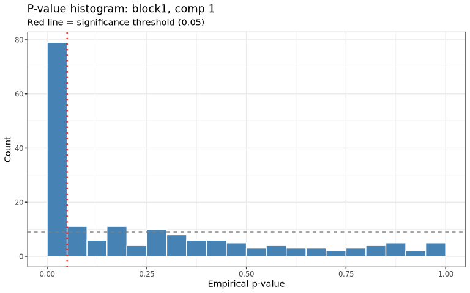

```r
plot_jackstraw(js)
```

```r
sig <- tryCatch(get_significant_vars(js, block = 1L, component = 1L),
                error = function(e) NULL)
if (!is.null(sig) && length(sig) > 0) {
  cat("Significant features (block 1, joint component 1):\n")
  cat(paste(head(sig, 20), collapse = "\n"), "\n")
  if (length(sig) > 20) cat("...and", length(sig) - 20, "more\n")
} else {
  message("No significant features for block 1, component 1.")
}
```

```
## Significant features (block 1, joint component 1):
## Adlercreutzia
## Agathobacter
## Alistipes
## Anaerotruncus
## Bifidobacteriaceae
## Bifidobacterium
## Blautia
## Butyricicoccus
## Butyrivibrio
## CAG-56
## Candidatus_Soleaferrea
## Caproiciproducens
## Christensenella
## Christensenellaceae
## Clostridium_sensu_stricto_1
## Coprococcus
## DTU089
## Desulfovibrionaceae
## Dialister
## Dorea
## ...and 33 more
```

# 12 Do clinical variables follow the joint axis?

```r
# Categorical variables
cat_vars <- c("Category", "Diagnosis", "Sexs")
cat_vars <- intersect(cat_vars, colnames(meta_s))

if (jr >= 1 && length(cat_vars) > 0) {
  assoc_list <- lapply(cat_vars, function(v) {
    tryCatch(
      associate_components(ajive_output = mb_fit, metadata = meta_s,
                           variable = v, mode = "categorical",
                           type = "joint"),
      error = function(e) NULL
    )
  })
  assoc_list <- Filter(Negate(is.null), assoc_list)
  for (p in assoc_list) if (inherits(p, "gg")) print(p)
}
```

[output not shown]

```r
# Continuous variables — SCFAs
cont_vars <- c("Acetate", "Propionate", "Butyrate")
cont_vars <- intersect(cont_vars, colnames(meta_s))

if (jr >= 1 && length(cont_vars) > 0) {
  assoc_cont <- lapply(cont_vars, function(v) {
    tryCatch(
      associate_components(ajive_output = mb_fit, metadata = meta_s,
                           variable = v, mode = "continuous",
                           type = "joint"),
      error = function(e) NULL
    )
  })
  assoc_cont <- Filter(Negate(is.null), assoc_cont)
  for (p in assoc_cont) if (inherits(p, "gg")) print(p)
}
```

# 13 Does the rank survive resampling?

```r
stab <- readRDS(file.path(data_dir, "microbiome_stability.rds"))
stab_summary <- tryCatch(summary(stab), error = function(e) NULL)
if (!is.null(stab_summary)) print(stab_summary)
```

```
##                   Length Class  Mode
## rank_distribution 30     -none- numeric
## rank_table         2     table  numeric
## observed_rank      1     -none- numeric
```

# 14 Conclusion

In this cached analysis, RaJIVE finds one joint component shared by Bacteria, Fungi, and Viruses, plus kingdom-specific individual components. The joint axis is the candidate ecosystem-wide signal: a host or treatment-associated pattern that crosses kingdom boundaries. The individual components capture the other half of the story, where each kingdom carries its own ecological structure.

The main takeaways are:

1. Bacteria, Fungi, and Viruses share a single covariation axis (`jr = 1`)
2. Jackstraw testing highlights features supporting that joint structure
3. The joint component can be screened against clinical categories
4. Individual components retain kingdom-specific biology that the joint axis intentionally leaves behind

# 16 Appendix: Cache generation script

The code below recreates the cached RDS files from the source data. It needs internet access to download from EBI FTP, so it is not evaluated during vignette builds.

```r
# ---- 0. Setup ----------------------------------------------------------------
library(rajiveplus)
library(dplyr)
library(tidyr)

out_dir <- "vignettes/data"
dir.create(out_dir, recursive = TRUE, showWarnings = FALSE)

# ---- 1. Download raw data from EBI FTP -------------------------------------
message("[1/6] Downloading raw data from EBI FTP...")
base_url <- paste0(
  "https://ftp.ebi.ac.uk/biostudies/nfs/S-BSST666/",
  "MOFA_tutorial_microbiome/")

kingdoms <- c(Bacteria = "16S_otu_abundances.csv",
              Fungi    = "ITS_otu_abundances.csv",
              Viruses  = "virome_otu_abundances.csv")
meta_file <- "sample_metadata.csv"

read_ebi <- function(file) {
  read.csv(url(paste0(base_url, file)), row.names = 1, check.names = FALSE)
}

raw_mats <- lapply(kingdoms, read_ebi)
metadata <- read_ebi(meta_file)

# CLR-normalise (add pseudo-count)
clr_norm <- function(X) {
  X <- X + 0.5
  log(X) - rowMeans(log(X))
}
raw_mats <- lapply(raw_mats, clr_norm)

# Convert to long format for storage
dt_long <- do.call(rbind, lapply(names(raw_mats), function(k) {
  m <- raw_mats[[k]]
  df <- as.data.frame(as.table(m))
  colnames(df) <- c("sample", "feature", "value")
  df$view <- k
  df[, c("sample", "feature", "view", "value")]
}))

raw <- list(dt = dt_long, metadata = metadata)
saveRDS(raw, file.path(out_dir, "microbiome_raw.rds"))
message("    -> saved microbiome_raw.rds")

# ---- 2. Preprocessing -------------------------------------------------------
message("[2/6] Preprocessing to matrix blocks...")
common_samples <- Reduce(intersect, lapply(raw_mats, rownames))
blocks <- lapply(raw_mats, function(m) m[common_samples, , drop = FALSE])
meta_s <- metadata[match(common_samples, rownames(metadata)), ]
rownames(meta_s) <- common_samples

message("    Views found: ", paste(names(blocks), collapse = ", "))
message("    Samples in common: ", length(common_samples))

pp <- list(blocks = blocks, meta = meta_s)
saveRDS(pp, file.path(out_dir, "microbiome_preprocessed.rds"))
message("    -> saved microbiome_preprocessed.rds")
message("    Block dims: ",
        paste(sapply(blocks, function(m) paste(dim(m), collapse = "x")),
              collapse = ", "))

# ---- 3. Per-block SVD for scree plots ---------------------------------------
message("[3/6] Computing per-block SVD for scree plots...")
svd_list <- lapply(blocks, function(m) {
  s <- svd(scale(m), nu = 0, nv = 0)$d
  s
})
saveRDS(svd_list, file.path(out_dir, "microbiome_svd_list.rds"))

init_ranks <- c(Bacteria = 5L, Fungi = 4L, Viruses = 3L)
message("    Initial signal ranks: ",
        paste(names(init_ranks), init_ranks, sep = "=", collapse = ", "))
message("    -> saved microbiome_svd_list.rds")

# ---- 4. Fit RaJIVE ----------------------------------------------------------
message("[4/6] Fitting Rajive() model...")
mb_fit <- Rajive(blocks, initial_signal_ranks = init_ranks, seed = 42L)
jr <- get_joint_rank(mb_fit)
message("    Estimated joint rank: ", jr)
saveRDS(mb_fit, file.path(out_dir, "microbiome_rajive_results.rds"))
message("    -> saved microbiome_rajive_results.rds")

# ---- 5. Jackstraw -----------------------------------------------------------
message("[5/6] Running jackstraw_rajive()...")
js <- jackstraw_rajive(mb_fit, blocks = blocks, n_null = 100L)
saveRDS(js, file.path(out_dir, "microbiome_jackstraw_results.rds"))
message("    -> saved microbiome_jackstraw_results.rds")

# ---- 6. Bootstrap stability -------------------------------------------------
message("[6/6] Bootstrap rank stability (B=30)...")
stab <- assess_stability(
  ajive_output        = mb_fit,
  blocks              = blocks,
  initial_signal_ranks = init_ranks,
  target              = "joint_rank",
  B                   = 30L,
  sample_frac         = 0.8,
  seed                = 43L)
saveRDS(stab, file.path(out_dir, "microbiome_stability.rds"))
message("    -> saved microbiome_stability.rds")
message("All 6 cache files generated successfully.")
```